# EAS 508 Assignment 1– Sainath Aittla, UB ID: 50557807

**Displacement:**

Shows a very strong positive correlation with horsepower and weight, and a high positive correlation with cylinders, indicating that larger displacement engines are more powerful, heavier, and typically have more cylinders. Negatively correlated with acceleration, year, and origin, suggesting that cars with smaller engines tend to be newer and possibly from origins other than the US. Horsepower:

Highly positively correlated with weight and displacement, and strongly correlated with cylinders. More powerful engines are heavier and have more cylinders. Has a strong negative correlation with acceleration, indicating that cars with less horsepower tend to accelerate faster.

**Weight:**

Strongly positively correlated with displacement, horsepower, and cylinders, meaning heavier cars tend to have larger and more powerful engines with more cylinders. Negatively correlated with acceleration, year, and origin, indicating that lighter cars tend to be newer and possibly from origins other than the US.

**Acceleration:**

Positively correlated with year and origin, but negatively correlated with all the engine-related variables (cylinders, displacement, horsepower, and weight), suggesting that newer, lighter, and possibly foreign cars have better acceleration. Year:

Positively correlated with mpg and acceleration, but negatively correlated with all engine-related variables and origin. This implies that newer models are more fuel-efficient and have better acceleration, and also there might have been changes in country of manufacture over the years.

**Origin:**

Positively correlated with mpg and acceleration, but negatively correlated with all engine-related variables, which could indicate that cars from certain regions are more fuel-efficient and have better acceleration characteristics.

**Top Predictor for MPG:**

Looking at the correlation coefficients for mpg, the variable with the strongest negative correlation is weight (-0.8322442), making it the top predictor for mpg among the variables listed. This means that the weight of a vehicle is the most strongly related single predictor of fuel efficiency, with heavier cars tending to be less fuel-efficient

- (c)[6 pts] perform a simple linear regression use MPG as response and the top predictor. Produce diagnostic plots of the linear regression fit (similar as the ones we showed on class to check the assumptions of linear regression: linearity, normality, constant variance). Interpret your discoveries.

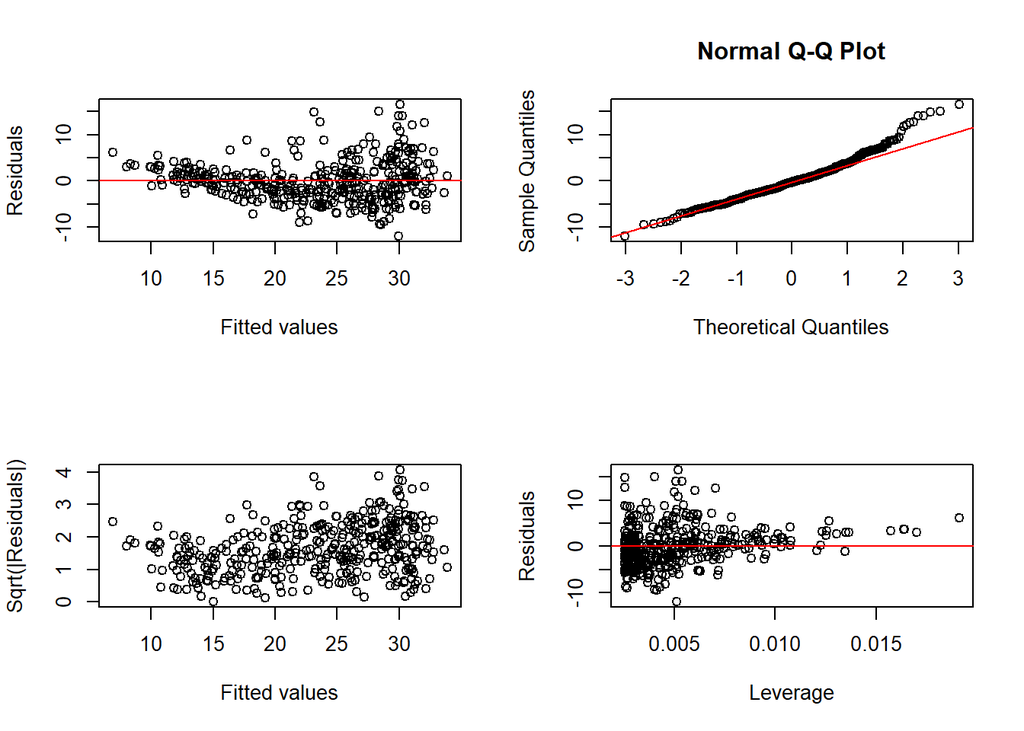

```r
model <- lm(mpg ~ weight, data=Auto)
par(mfrow=c(2,2))
plot(model$fitted.values, resid(model), xlab="Fitted values", ylab="Residuals")
abline(h=0, col="red")
qqnorm(resid(model))
qqline(resid(model), col="red")
plot(model$fitted.values, sqrt(abs(resid(model))), xlab="Fitted values", ylab="Sqrt(|Residuals|)")
plot(hatvalues(model), resid(model), xlab="Leverage", ylab="Residuals")
abline(h=0, col="red")
```

```r
par(mfrow=c(1,1))
```

The diagnostic plots provided are used to evaluate the assumptions of linear regression. Here’s the interpretation of each plot:

**Residuals vs Fitted Plot:**

This plot is used to check the assumption of linearity and homoscedasticity (constant variance) of residuals. Ideally, the residuals should be randomly scattered around the horizontal line (red line) at zero, with no discernible pattern. In the provided plot, the residuals do not appear to have a clear pattern, which is good for linearity. However, there seems to be a slight “fanning” effect, where the spread of residuals increases with the fitted values. This could be an indication of heteroscedasticity.

**Normal Q-Q Plot:**

This plot checks whether the residuals are normally distributed. Points following the straight line (red line) indicate normality. The plot shows that lower and higher quantiles of residuals deviate from the line, suggesting that the residuals may have a non-normal distribution, particularly in the tails.

**Scale-Location (or Spread-Location) Plot:**

**Residuals vs Leverage Plot:**

This plot identifies influential cases that might have an undue influence on the regression line. Points far from the center of the plot horizontally are high leverage points, and points far from zero vertically are large residuals. The Cook’s distance lines help to identify influential points. Any point outside the Cook’s distance lines would be considered influential. There appear to be a few points with higher leverage, but without a clear Cook’s distance line, it’s hard to say if they are influential. The residuals do not show any extreme outliers.

Overall, the diagnostic plots suggest that while the assumption of linearity is fairly well met, there are concerns regarding the normality of residuals and homoscedasticity. The residuals might not be perfectly normally distributed, especially in the tails, and there appears to be heteroscedasticity, as the spread of residuals increases with the fitted values. There are no obvious influential outliers based on the leverage plot, but further investigation might be warranted. These issues might be addressed with transformations or other adjustments to the model.

- (d)[4 pts] Use the `lm()` function to perform a multiple linear regression with mpg as the response and all other variables except name as the predictors. Use the summary() function to print the results. Comment on the output. For instance:
  - 1. Is there a relationship between the predictors and the response?
  - 2. Which predictors appear to have a statistically significant relationship to the response?
  - 3. What does the coefficient for the year variable suggest?

```r
df_numeric <- Auto[, -which(names(Auto) == "name")]
model <- lm(mpg ~ ., data = df_numeric)
summary(model)
```

```
##
## Call:
## lm(formula = mpg ~ ., data = df_numeric)
##
## Residuals:
##     Min      1Q  Median      3Q     Max
## -9.5903 -2.1565 -0.1169  1.8690 13.0604
##
## Coefficients:
##                Estimate Std. Error t value Pr(>|t|)
## (Intercept)  -17.218435   4.644294  -3.707  0.00024 ***
## cylinders     -0.493376   0.323282  -1.526  0.12780
## displacement   0.019896   0.007515   2.647  0.00844 **
## horsepower    -0.016951   0.013787  -1.230  0.21963
## weight        -0.006474   0.000652  -9.929  < 2e-16 ***
## acceleration   0.080576   0.098845   0.815  0.41548
## year           0.750773   0.050973  14.729  < 2e-16 ***
## origin         1.426141   0.278136   5.127 4.67e-07 ***
## ---
## Signif. codes:  0 '***' 0.001 '**' 0.01 '*' 0.05 '.' 0.1 ' ' 1
##
## Residual standard error: 3.328 on 384 degrees of freedom
## Multiple R-squared:  0.8215, Adjusted R-squared:  0.8182
## F-statistic: 252.4 on 7 and 384 DF,  p-value: < 2.2e-16
```

**(i)** Yes, there is a relationship between the predictors and the response. This is indicated by the F-statistic and its associated p-value (F-statistic: 252.4 on 7 and 384 DF, p-value: < 2.2e-16), which tests the null hypothesis that all regression coefficients are equal to zero. The very small p-value suggests that we can reject the null hypothesis and conclude that there is a statistically significant relationship between the predictors as a group and the response variable mpg.

**(ii)** The predictors that have a statistically significant relationship with the response mpg at the 0.05 level (or lower) are:

displacement (p-value: 0.00844, significant at the 0.01 level)

weight (p-value: < 2e-16, highly significant)

year (p-value: < 2e-16, highly significant)

origin (p-value: 4.67e-07, highly significant)

These variables’ coefficients are significantly different from zero, indicating they have a unique contribution to the model in predicting mpg.

**(iii)** The coefficient for the year variable is 0.750773, which is statistically significant (p-value: < 2e-16). This suggests that for each additional year, the mpg is expected to increase by approximately 0.75, holding all other variables constant. In other words, newer models of cars are expected to be more fuel-efficient, with a yearly improvement in mpg of about 0.75 miles per gallon. This reflects the trend over time of improving fuel efficiency in vehicles, potentially due to advancements in technology, regulatory changes, or other factors.

- (e)[5 pts] Produce diagnostic plots of the linear regression fit. Comment on any problems you see with the fit. Do the residual plots suggest any unusually large outliers? Does the leverage plot identify any observations with unusually high leverage?

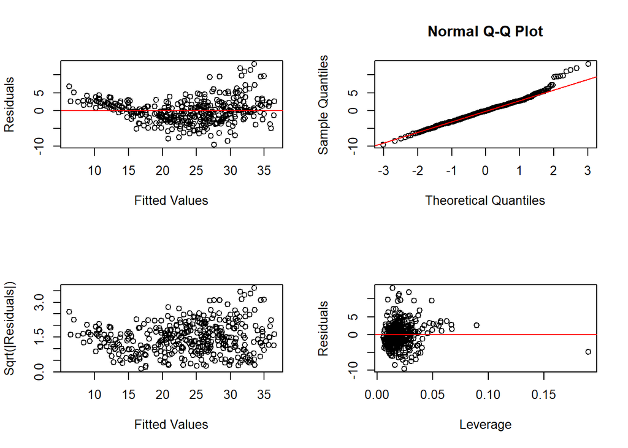

```r
model <- lm(mpg ~ ., data = df_numeric)
par(mfrow=c(2,2))
plot(model$fitted.values, resid(model), xlab="Fitted Values", ylab="Residuals")
abline(h=0, col="red")
qqnorm(resid(model))
qqline(resid(model), col="red")
plot(model$fitted.values, sqrt(abs(resid(model))), xlab="Fitted Values", ylab="Sqrt(|Residuals|)")
plot(hatvalues(model), resid(model), xlab="Leverage", ylab="Residuals")
abline(h=0, col="red")
```

```r
par(mfrow=c(1,1))
```

The diagnostic plots for the linear regression model give us insights into the presence of outliers and influential observations:

**Residuals vs Fitted Plot:** This plot does not show any residuals that are dramatically larger than the others. While there are some points that lie outside the general cloud of points (a few above or below), they don’t appear to be excessively distant from the zero line, suggesting no extremely large outliers in terms of residuals.

**Normal Q-Q Plot:** This plot shows the residuals against their expected values if they were normally distributed. The points largely follow the reference line, with slight deviations at the tails. This is fairly typical and doesn’t indicate any extreme outliers that are problematic for the normality assumption.

- 6. [5 pts] Fit a multiple linear regression model called model_tops using MPG as the response and the top 3 predicting variables with the strongest relationship with MPG. Compare the coefficients of the 3 predictor in model_tops with the model that used all numeric predictors, which ones are larger? Why?

```r
model_tops <- lm(mpg ~ weight + displacement + year, data=Auto)
summary(model_tops)
```

```
##
## Call:
## lm(formula = mpg ~ weight + displacement + year, data = Auto)
##
## Residuals:
##     Min      1Q  Median      3Q     Max
## -8.8400 -2.2917 -0.1177  2.0420 14.3559
##
## Coefficients:
##                Estimate Std. Error t value Pr(>|t|)
## (Intercept)  -1.436e+01  4.021e+00  -3.572 0.000398 ***
## weight       -6.664e-03  5.710e-04 -11.670  < 2e-16 ***
## displacement  2.835e-04  4.744e-03   0.060 0.952382
## year          7.580e-01  5.100e-02  14.863  < 2e-16 ***
## ---
## Signif. codes:  0 '***' 0.001 '**' 0.01 '*' 0.05 '.' 0.1 ' ' 1
##
## Residual standard error: 3.432 on 388 degrees of freedom
## Multiple R-squared:  0.8082, Adjusted R-squared:  0.8067
## F-statistic: 544.9 on 3 and 388 DF,  p-value: < 2.2e-16
```

To compare the coefficients of the 3 predictors in model_tops with those in the full model that used all numeric predictors, we can look at the estimates directly:

From model_tops:

weight: -0.006664 (strongly negative) displacement: 0.0002835 (close to zero, and not statistically significant with a p-value of 0.952382) year: 0.7580 (positive)

From the full model:

weight: -0.006474 displacement: 0.019896 year: 0.750773 Comparing the coefficients:

The coefficient for weight in model_tops is slightly larger (in absolute value) than in the full model. This suggests that when the model is simplified and only includes the top predictors, the impact of weight on MPG becomes slightly more pronounced. This could be due to the removal of other variables that were accounting for some of the variability in MPG that is actually due to weight.

The coefficient for displacement in model_tops is much smaller than in the full model and is not statistically significant. This change suggests that displacement’s effect in the full model may have been confounded with the effects of other variables that were not included in model_tops.

The coefficient for year is slightly larger in model_tops compared to the full model, indicating a stronger relationship with MPG when the model is restricted to fewer predictors. Similar to weight, this could be because other variables in the full model were capturing some of the year’s effect.

The differences in the coefficients between the models can be due to several reasons:

**Multicollinearity:** When multiple predictors in the model are correlated with each other, it can distort the apparent effect of each predictor on the response variable. Removing some predictors can change the estimated relationships.

**Omitted Variable Bias:** If the full model includes variables that are important for predicting the response, then omitting these variables in a smaller model can bias the coefficients of the included predictors.

**Overfitting:** The full model may have been overfitting the data, capturing noise rather than signal. This can inflate or deflate coefficients artificially, and when a simpler model is used, the coefficients may reflect the underlying relationship more accurately.

In the given scenario, the change in the coefficient for displacement is the most dramatic, indicating that its relationship with MPG is not robust across different model specifications. Weight and year maintain their significance and direction of effect, with slight increases in their absolute impact on MPG in the simpler model.

- (g)[3 pts] Use the * and : symbols to fit linear regression models with interaction effects. Do any interactions appear to be statistically significant?

```r
model_interaction <- lm(mpg ~ weight * displacement * year, data = Auto)
summary(model_interaction)
```

```
##
## Call:
## lm(formula = mpg ~ weight * displacement * year, data = Auto)
##
## Residuals:
##     Min      1Q  Median      3Q     Max
## -9.6093 -1.6472 -0.0531  1.2289 14.5604
##
## Coefficients:
##                            Estimate Std. Error t value Pr(>|t|)
## (Intercept)              -8.437e+01  3.128e+01  -2.697   0.0073 **
## weight                    8.489e-03  1.322e-02   0.642   0.5212
## displacement              3.434e-01  1.969e-01   1.744   0.0820 .
## year                      1.828e+00  4.127e-01   4.430 1.23e-05 ***
## weight:displacement      -6.589e-05  5.055e-05  -1.303   0.1932
## weight:year              -2.433e-04  1.744e-04  -1.395   0.1638
## displacement:year        -5.566e-03  2.674e-03  -2.082   0.0380 *
## weight:displacement:year  1.144e-06  6.823e-07   1.677   0.0944 .
## ---
## Signif. codes:  0 '***' 0.001 '**' 0.01 '*' 0.05 '.' 0.1 ' ' 1
##
## Residual standard error: 2.951 on 384 degrees of freedom
## Multiple R-squared:  0.8596, Adjusted R-squared:  0.8571
## F-statistic:   336 on 7 and 384 DF,  p-value: < 2.2e-16
```

In the model summary provided, we see several interaction terms included in the regression model. Here’s an analysis of their statistical significance based on the provided p-values:

weight:displacement (Interaction between weight and displacement):

Estimate: -6.589e-05 p-value: 0.1932 This interaction term is not statistically significant at the conventional 0.05 level. weight:year (Interaction between weight and year):

Estimate: -2.433e-04 p-value: 0.1638 This interaction term is not statistically significant at the conventional 0.05 level. displacement:year (Interaction between displacement and year):

Estimate: -5.566e-03 p-value: 0.0380 This interaction term is statistically significant at the 0.05 level, indicating that the effect of displacement on MPG changes with the year. weight:displacement:year (Three-way interaction between weight, displacement, and year):

Estimate: 1.144e-06 p-value: 0.0944 This three-way interaction term is not statistically significant at the conventional 0.05 level, but is marginally significant (p-value is less than 0.1). Based on these results, the only statistically significant interaction at the 0.05 level is between displacement and year. This suggests that the relationship between engine displacement and fuel efficiency (MPG) has changed over the years. The three-way interaction is marginally significant, suggesting there might be a more complex relationship between all three variables over time, but this result is not strong enough to be conclusive at the 0.05 level.

- (h)[5 pts] Try a few different transformations of the variables, such as $\log(X), \sqrt{X}, X^2$. Comment on your findings.

```r
model_log <- lm(log(mpg) ~ log(weight) + log(displacement) + year, data = Auto)
model_sqrt <- lm(sqrt(mpg) ~ sqrt(weight) + sqrt(displacement) + year, data = Auto)
model_squared <- lm(mpg ~ I(weight^2) + I(displacement^2) + year, data = Auto)
summary(model_log)
```

```
##
## Call:
## lm(formula = log(mpg) ~ log(weight) + log(displacement) + year,
##     data = Auto)
##
## Residuals:
##      Min       1Q   Median       3Q      Max
## -0.42199 -0.06752  0.00321  0.06498  0.42553
##
## Coefficients:
##                    Estimate Std. Error t value Pr(>|t|)
## (Intercept)        7.337783   0.367315  19.977   <2e-16 ***
## log(weight)       -0.782428   0.063276 -12.365   <2e-16 ***
## log(displacement) -0.086607   0.033892  -2.555    0.011 *
## year               0.032010   0.001705  18.776   <2e-16 ***
## ---
## Signif. codes:  0 '***' 0.001 '**' 0.01 '*' 0.05 '.' 0.1 ' ' 1
##
## Residual standard error: 0.1169 on 388 degrees of freedom
## Multiple R-squared:  0.8827, Adjusted R-squared:  0.8818
## F-statistic: 973.4 on 3 and 388 DF,  p-value: < 2.2e-16
```

```r
summary(model_sqrt)
```

```
##
## Call:
## lm(formula = sqrt(mpg) ~ sqrt(weight) + sqrt(displacement) +
##     year, data = Auto)
##
## Residuals:
##      Min       1Q   Median       3Q      Max
## -0.96729 -0.19060  0.01219  0.17662  1.09195
##
## Coefficients:
##                     Estimate Std. Error t value Pr(>|t|)
## (Intercept)         3.098528   0.383611   8.077 8.45e-15 ***
## sqrt(weight)       -0.070895   0.005869 -12.079  < 2e-16 ***
## sqrt(displacement) -0.019212   0.012584  -1.527    0.128
## year                0.075883   0.004456  17.029  < 2e-16 ***
## ---
## Signif. codes:  0 '***' 0.001 '**' 0.01 '*' 0.05 '.' 0.1 ' ' 1
##
## Residual standard error: 0.3022 on 388 degrees of freedom
## Multiple R-squared:  0.8595, Adjusted R-squared:  0.8584
## F-statistic: 790.9 on 3 and 388 DF,  p-value: < 2.2e-16
```

```r
summary(model_squared)
```

```
##
## Call:
## lm(formula = mpg ~ I(weight^2) + I(displacement^2) + year, data = Auto)
##
## Residuals:
##     Min      1Q  Median      3Q     Max
## -9.7576 -2.6738 -0.1461  2.2934 15.0042
##
## Coefficients:
##                     Estimate Std. Error t value Pr(>|t|)
## (Intercept)       -2.546e+01  4.389e+00  -5.800 1.37e-08 ***
## I(weight^2)       -1.090e-06  8.419e-08 -12.945  < 2e-16 ***
## I(displacement^2)  1.333e-05  9.612e-06   1.387    0.166
## year               7.726e-01  5.674e-02  13.616  < 2e-16 ***
## ---
## Signif. codes:  0 '***' 0.001 '**' 0.01 '*' 0.05 '.' 0.1 ' ' 1
##
## Residual standard error: 3.797 on 388 degrees of freedom
## Multiple R-squared:  0.7651, Adjusted R-squared:  0.7633
## F-statistic: 421.3 on 3 and 388 DF,  p-value: < 2.2e-16
```

The model summaries for the three transformations show how each model performs with the transformed variables. Here’s a summary of the findings:

**Log-Transformed Model:**

Adjusted R-squared: 0.8818, which indicates that about 88.18% of the variability in the log of mpg is explained by the model. Residual standard error: 0.1169, which is relatively low, suggesting a good fit. All predictors are statistically significant, with p-values less than 0.05. The coefficients for log(weight) and year are particularly significant, with a strong negative relationship for log(weight) and a positive relationship for year.

**Square Root-Transformed Model:**

Adjusted R-squared: 0.8584, which indicates that about 85.84% of the variability in the square root of mpg is explained by the model. Residual standard error: 0.3022, which is higher than the log-transformed model, suggesting a slightly worse fit. The predictors sqrt(weight) and year are statistically significant, but sqrt(displacement) is not (p-value: 0.128).

**Squared Model:**

Adjusted R-squared: 0.7633, which indicates that about 76.33% of the variability in mpg is explained by the model. This is lower than both the log-transformed and the square root-transformed models. Residual standard error: 3.797, which is higher than the other models, suggesting a less adequate fit. The squared term of weight is highly significant, while the squared term of displacement is not (p-value: 0.166). The year remains significant.

**Interpretation of Findings:**

The log transformation of both the response and predictors results in the highest adjusted R-squared value, which suggests that this transformation leads to a model that explains the variability in mpg more effectively than the other transformations.

The significance of the year variable across all models reinforces the understanding that newer cars tend to be more fuel-efficient.

The weight of the car consistently shows a strong negative effect on mpg across all models. However, the nature of the relationship (whether linear, logarithmic, or square root) changes the magnitude of the coefficient and the interpretation.

The displacement does not appear to be a consistent predictor across the different transformations. While it is significant in the log model, it is not in the square root and squared models. This inconsistency may suggest that the relationship between displacement and mpg is not straightforward and may be influenced by other factors or interactions not captured in these models.

The log-transformed model generally provides the best fit based on the summary statistics, suggesting that the relationship between the predictors and mpg is multiplicative or exponential rather than additive. This can be the case in many real-world scenarios where the effect of predictors on the response variable increases or decreases proportionally.

In conclusion, the log transformation seems most appropriate for these data, as indicated by the model fit statistics. It would be beneficial to perform diagnostic checks on the log-transformed model to ensure that the residuals meet the assumptions of linear regression. Additionally, considering the context and the units of the variables, the log transformation may also provide a more interpretable model in terms of percentage changes rather than absolute changes.